# Exercícios dplyr e ggplot2 - MQuinho de inverno

Rômulo Damasceno

6/22/2021

## Proposta

Para esta lista de exercícios utilizaremos o banco de dados “gapminder”, que possui informações demográficas sobre países e continentes, de 1952 a 2007. A ideia é que ao finalizar esta lista, você tenha uma série de objetos e informações interessantes que permitirão a criação do seu primeiro projeto de portfólio!

## Passo 1 - Instalar e carregar os pacotes

1. Instale o pacote gapminder com a função install.packages()
2. Com a função library(), carregue os pacotes:
   - tidyverse
   - scales
   - gapminder
3. Atribua o banco de dados gapminder a um objeto de nome “bd_demog”

```r
# Resposta aqui

#1
#install.packages('gapminder')

#2
library(gapminder)
library(tidyverse)
library(scales)
#3
bd_demog <- gapminder
```

## Passo 2 - Estrutura do banco de dados

1. Utilize a função colnames(), head(), tail() e View() no banco de dados. Pense sobre o que cada uma delas faz.
2. Utilizando a função str(), analise a estrutura do banco de dados. As variáveis estão no formato correto?
3. Utilize a função summary() no banco de dados e reflita sobre quais das informações podem ser aproveitadas e quais precisam de maior aprofundamento. Faz sentido olhar para a expectativa de vida de todos os países ao mesmo tempo, por exemplo?

```r
#Respostas aqui
#Primeira pergunta
colnames(bd_demog)
```

```
## [1] "country"   "continent" "year"      "lifeExp"   "pop"       "gdpPercap"
```

```r
head(bd_demog)
```

```
## # A tibble: 6 x 6
##   country     continent  year lifeExp      pop gdpPercap
##   <fct>       <fct>     <int>   <dbl>    <int>     <dbl>
## 1 Afghanistan Asia       1952    28.8  8425333      779.
## 2 Afghanistan Asia       1957    30.3  9240934      821.
## 3 Afghanistan Asia       1962    32.0 10267083      853.
## 4 Afghanistan Asia       1967    34.0 11537966      836.
## 5 Afghanistan Asia       1972    36.1 13079460      740.
## 6 Afghanistan Asia       1977    38.4 14880372      786.
```

```r
tail(bd_demog)
```

```
## # A tibble: 6 x 6
##   country  continent  year lifeExp      pop gdpPercap
##   <fct>    <fct>     <int>   <dbl>    <int>     <dbl>
## 1 Zimbabwe Africa     1982    60.4  7636524      789.
## 2 Zimbabwe Africa     1987    62.4  9216418      706.
## 3 Zimbabwe Africa     1992    60.4 10704340      693.
## 4 Zimbabwe Africa     1997    46.8 11404948      792.
## 5 Zimbabwe Africa     2002    40.0 11926563      672.
## 6 Zimbabwe Africa     2007    43.5 12311143      470.
```

```r
View(bd_demog)
```

```r
#Segunda pergunta
str(bd_demog)
```

```
## tibble [1,704 x 6] (S3: tbl_df/tbl/data.frame)
##  $ country  : Factor w/ 142 levels "Afghanistan",..: 1 1 1 1 1 1 1 1 1 1 ...
##  $ continent: Factor w/ 5 levels "Africa","Americas",..: 3 3 3 3 3 3 3 3 3 3 ...
##  $ year     : int [1:1704] 1952 1957 1962 1967 1972 1977 1982 1987 1992 1997 ...
##  $ lifeExp  : num [1:1704] 28.8 30.3 32 34 36.1 ...
##  $ pop      : int [1:1704] 8425333 9240934 10267083 11537966 13079460 14880372 12881816 13867957 16317921 22227415 ...
##  $ gdpPercap: num [1:1704] 779 821 853 836 740 ...
```

```r
#Terceira pergunta - Não faz sentido
summary(bd_demog)
```

```
##         country        continent        year         lifeExp
##  Afghanistan:  12   Africa  :624   Min.   :1952   Min.   :23.60
##  Albania    :  12   Americas:300   1st Qu.:1966   1st Qu.:48.20
##  Algeria    :  12   Asia    :396   Median :1980   Median :60.71
##  Angola     :  12   Europe  :360   Mean   :1980   Mean   :59.47
##  Argentina  :  12   Oceania : 24   3rd Qu.:1993   3rd Qu.:70.85
##  Australia  :  12                  Max.   :2007   Max.   :82.60
##  (Other)    :1632
##       pop              gdpPercap
##  Min.   :6.001e+04   Min.   :   241.2
##  1st Qu.:2.794e+06   1st Qu.:  1202.1
##  Median :7.024e+06   Median :  3531.8
##  Mean   :2.960e+07   Mean   :  7215.3
##  3rd Qu.:1.959e+07   3rd Qu.:  9325.5
##  Max.   :1.319e+09   Max.   :113523.1
##
```

```r
brazil <- bd_demog %>%
  filter(country == "Brazil")

summary(brazil) #Agora o summary faz mais sentido
```

```
##         country      continent       year         lifeExp
##  Brazil     :12   Africa  : 0   Min.   :1952   Min.   :50.92
##  Afghanistan: 0   Americas:12   1st Qu.:1966   1st Qu.:57.14
##  Albania    : 0   Asia    : 0   Median :1980   Median :62.41
##  Algeria    : 0   Europe  : 0   Mean   :1980   Mean   :62.24
##  Angola     : 0   Oceania : 0   3rd Qu.:1993   3rd Qu.:67.64
##  Argentina  : 0                 Max.   :2007   Max.   :72.39
##  (Other)    : 0
##       pop              gdpPercap
##  Min.   : 56602560   Min.   :2109
##  1st Qu.: 85047215   1st Qu.:3407
##  Median :121638445   Median :6805
##  Mean   :122312127   Mean   :5829
##  3rd Qu.:159118660   3rd Qu.:7845
##  Max.   :190010647   Max.   :9066
##
```

## Passo 3 - Filtragem de um continente para análise

1. Utilizando a função filter(), do dplyr, escolha um continente para aprofundar sua análise e salve num objeto separado.
2. Utilize a função summary() neste novo objeto. As estatísticas básicas mostradas fazem mais sentido agora?

```r
# Respostas aqui
#Primeira pergunta
americas_continent <- bd_demog  %>%
     filter(continent == "Americas")
```

```r
#Segunda pergunta
summary(americas_continent)
```

```
##       country       continent        year         lifeExp
##  Argentina: 12   Africa  :  0   Min.   :1952   Min.   :37.58
##  Bolivia  : 12   Americas:300   1st Qu.:1966   1st Qu.:58.41
##  Brazil   : 12   Asia    :  0   Median :1980   Median :67.05
##  Canada   : 12   Europe  :  0   Mean   :1980   Mean   :64.66
##  Chile    : 12   Oceania :  0   3rd Qu.:1993   3rd Qu.:71.70
##  Colombia : 12                  Max.   :2007   Max.   :80.65
##  (Other)  :228
##       pop              gdpPercap
##  Min.   :   662850   Min.   : 1202
##  1st Qu.:  2962359   1st Qu.: 3428
##  Median :  6227510   Median : 5466
##  Mean   : 24504795   Mean   : 7136
##  3rd Qu.: 18340309   3rd Qu.: 7830
##  Max.   :301139947   Max.   :42952
##
```

## Passo 4 - Análise descritiva

### 4.1. Média da expectativa de vida por país

Qual é a média da expectativa de vida para cada país no período? Quais os três países que possuem a maior expectativa de vida? Quais três tem as menores? Salve o resultado num objeto separado chamado “seucontinente_lifeExp”

**Dicas:**

1. Para responder à primeira questão, utilize a função group_by() para a coluna country e então utilize o summarise() com o argumento mean() para calcular as médias agrupadas.
2. Utilizando a função arrange(), reordene as expectativas de vida encontradas em ordem decrescente, para responder a segunda parte da questão.
3. Salve o resultado desse código num banco chamado “seucontinente_lifeExp”

```r
# Respostas aqui
americas_lifeExp <- americas_continent %>%
                      group_by(country) %>%
                      summarise(media_lifeExp = mean(lifeExp)) %>%
                      arrange(desc(media_lifeExp))
```

```r
head(americas_lifeExp,3)
```

```
## # A tibble: 3 x 2
##   country       media_lifeExp
##   <fct>                 <dbl>
## 1 Canada                 74.9
## 2 United States          73.5
## 3 Puerto Rico            72.7
```

```r
tail(americas_lifeExp, 3)
```

```
## # A tibble: 3 x 2
##   country   media_lifeExp
##   <fct>             <dbl>
## 1 Guatemala          56.7
## 2 Bolivia            52.5
## 3 Haiti              50.2
```

### 4.2. Identificar os países com expectativas de vida inferiores e superiores a média dos países.

Crie uma nova coluna no banco seucontinente_lifeExp com um identificador de países que estão acima ou abaixo da média da coluna media_lifeExp.

**Dicas:**

1. Utilize a função mean() para identificar a média da coluna media_lifeExp
2. Utilize as funções mutate() e case_when(), para criar uma nova variável chamada **classificacao_lifeExp**, que tem dois níveis de resposta: “Abaixo da média” e “Acima da média”.

```r
#Respostas aqui
#Minha Resposta
media_lifeExp <- americas_lifeExp %>%
                 summarise(mean(mean))
#classicacao_lifeExp <- americas_continent %>%
                      #mutate(case_when(media_lifeExp > mean ~ "Acima da media"))
```

```r
#Correção

americas_lifeExp <- americas_lifeExp %>%
  mutate(classificacao_lifeExp = case_when(
    media_lifeExp <= mean(media_lifeExp) ~ "Abaixo da média",
    media_lifeExp > mean(media_lifeExp) ~"Acima da média"  ))
```

## Passo 5 - Visualizações com o ggplot2

### 5.1. Barras

Utilize o vetor que contém as médias de expectativa de vida por país e crie um gráfico de barras.

**Dicas:**

1. Como as expectativas de vida vão ficar no eixo Y e o geom_bar() não aceita a definição de um eixo Y, utilize o geom_col().

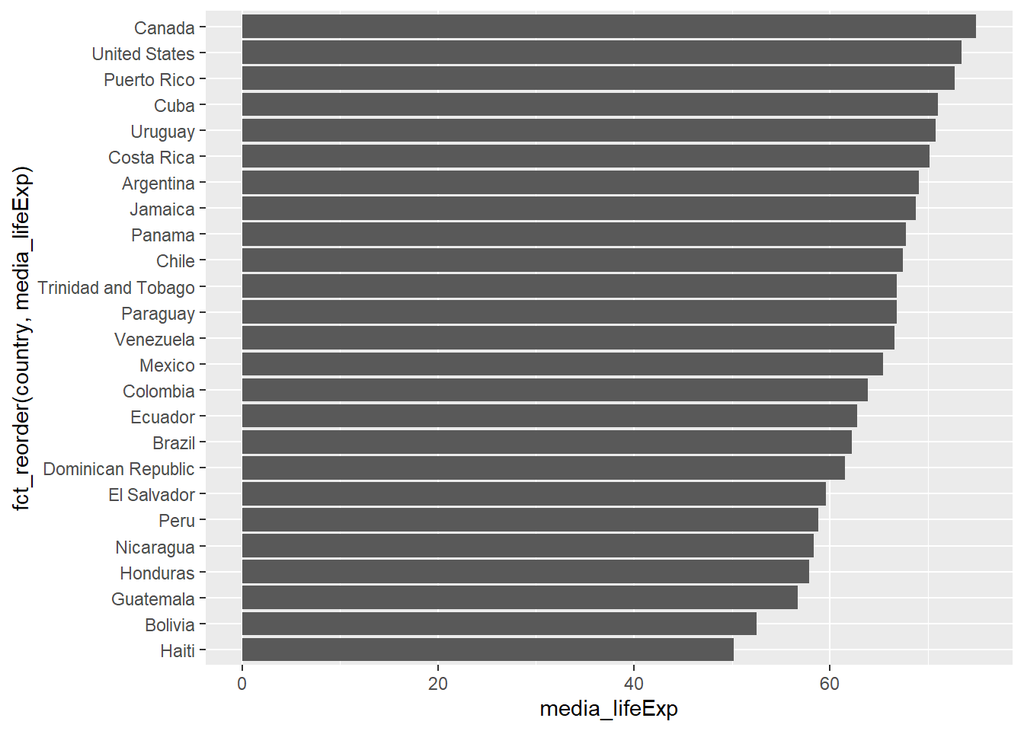

```r
#Respostas aqui
americas_lifeExp %>%
  ggplot(mapping = aes(x = fct_reorder(country, media_lifeExp),
                       y = media_lifeExp)) +
  geom_col() +
  coord_flip()
```

### 5.2. Histograma

Utilize o vetor do seu continente para criar um histograma de todas as expectativas de vida neste continente.

**Dicas:**

1. O geom utilizado é o geom_histogram()

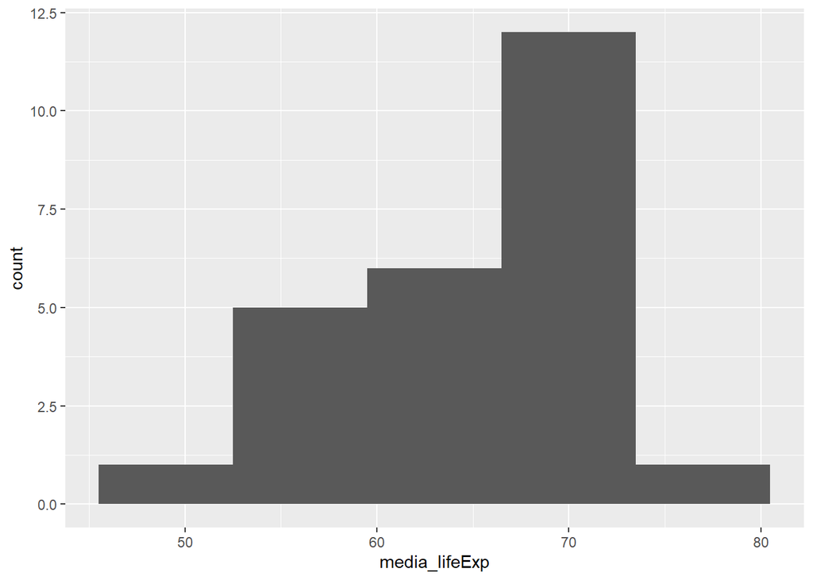

```r
#Respostas aqui
americas_lifeExp %>%
  ggplot(mapping = aes(x = media_lifeExp)) +
  stat_bin(binwidth = 7) +
  geom_histogram()
```

### 5.3. Boxplot

Escolha três países para comparar a variável de PIB per capita (gdpPercap) e crie um boxplot que contenha no eixo X os países, no eixo Y a variável gdpPercap e que as cores das caixinhas (fill) sejam pintadas de acordo com o país.

**Dicas:**

1. O geom utilizado é o geom_boxplot()

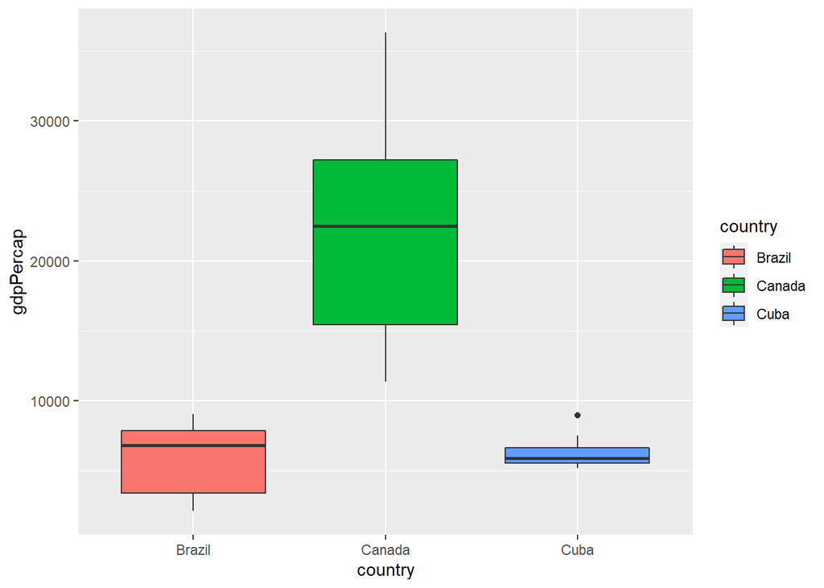

```r
#Respostas aqui
americas_continent %>%
  filter(country %in% c('Brazil', 'Canada', 'Cuba')) %>%
  ggplot(mapping = aes(x = country,
                       y = gdpPercap,
                       fill = country)) +
  geom_boxplot()
```

### 5.4. Diagrama de dispersão

Crie um gráfico de dispersão entre as variáveis de PIB per capita e expectativa de vida. As variáveis estão correlacionadas? Adicione uma linha de suavização para identificar o formato da distribuição.

**Dicas:**

1. Os geoms utilizados aqui são: geom_point() para criação do diagrama de dispersão e geom_smooth() para criação da linha de suavização
2. Por se tratar de um gráfico de pontos, o valor definido para o eixo X e eixo Y não alteram sua interpretação.

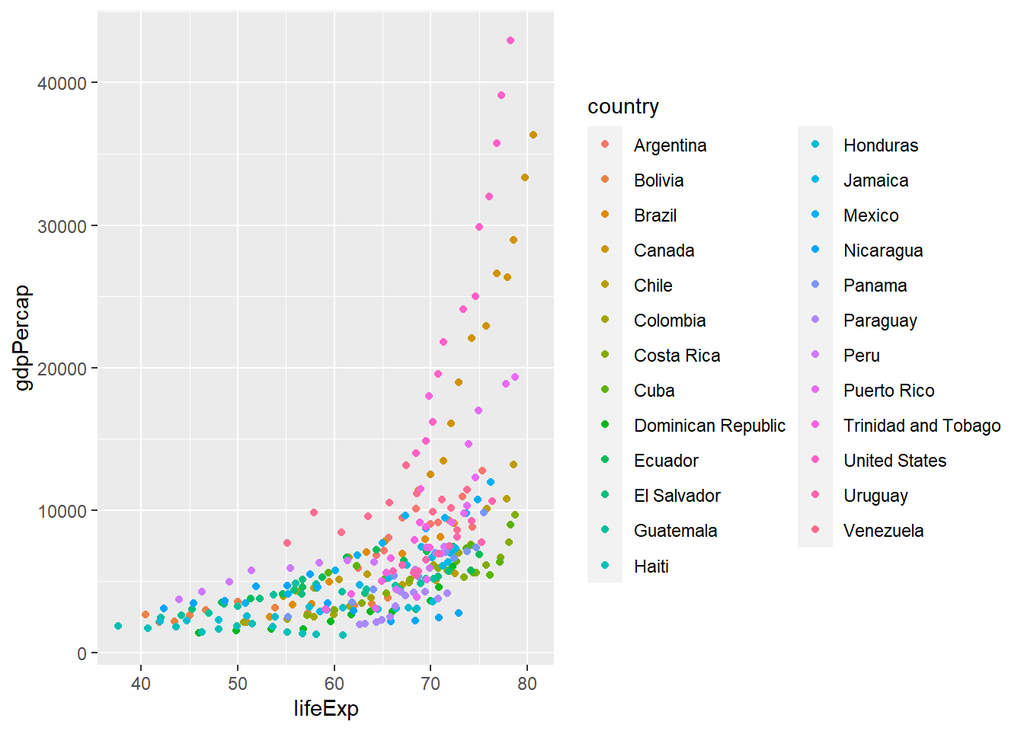

```r
#Respostas aqui
americas_continent %>%
  ggplot(mapping = aes(x = lifeExp,
                       y = gdpPercap,
                       colour = country)) +
  geom_point()
```

### 5.5. Linha

Selecione quatro países do seu continente e faça um gráfico de linhas demostrando a progressão das expectativas de vida de cada país ao longo do período de 1952 a 2007. Além disso, defina que as cores das linhas serão correspondentes aos países.

**Dicas:**

1. Os anos deverão estar no eixo X.
2. O argumento para definir as cores das linhas é o colour(), e deverá estar no argumento de definição dos eixos.

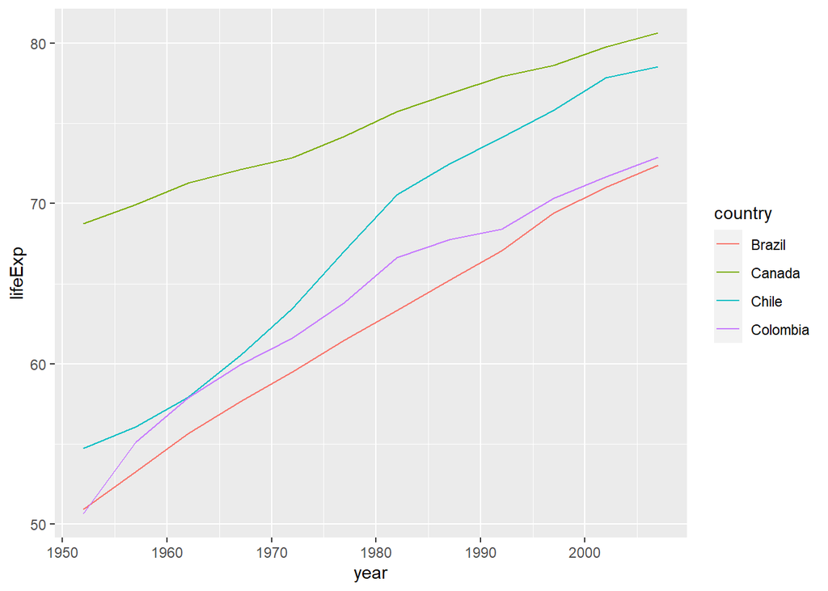

```r
#Respostas aqui
americas_continent %>%
  filter(country %in% c('Brazil','Canada', 'Chile', 'Colombia')) %>%
  ggplot(mapping = aes(x = year,
                       y = lifeExp,
                       colour = country)) +
  geom_line()
```